# Practical Data Wrangling With R Day Two

# Summarizing And Grouping

If we recall, we already saw a little bit of grouping and merging (if you don’t, you might remember that mess with aggregate). Given that we already saw aggregate, we will just dive right into the tidyverse.

## dplyr

Grouping data and comparing various summary statistics by group is a common task. Sometimes it is just a means of exploration and sometimes it will actually answer the question. No matter the need, you will likely find it quite simple.

```r
library(dplyr)

mtcars %>%
  summarize(meanMPG = mean(mpg),
            meanSD = sd(mpg))
```

```
   meanMPG   meanSD
1 20.09062 6.026948
```

You can even summarize all of your variables in a handy way.

```r
mtcars %>%
  summarize_all(funs(mean, sd), na.rm = TRUE)
```

```
  mpg_mean cyl_mean disp_mean  hp_mean drat_mean wt_mean qsec_mean vs_mean
1 20.09062   6.1875  230.7219 146.6875  3.596563 3.21725  17.84875  0.4375
  am_mean gear_mean carb_mean   mpg_sd   cyl_sd  disp_sd    hp_sd
1 0.40625    3.6875    2.8125 6.026948 1.785922 123.9387 68.56287
    drat_sd     wt_sd  qsec_sd     vs_sd     am_sd   gear_sd carb_sd
1 0.5346787 0.9784574 1.786943 0.5040161 0.4989909 0.7378041  1.6152
```

Because we are dealing with the tidyverse, variable selection is included.

```r
mtcars %>%
  summarize_at(vars(starts_with("c")),
               funs(mean, sd), na.rm = TRUE)
```

```
  cyl_mean carb_mean   cyl_sd carb_sd
1   6.1875    2.8125 1.785922  1.6152
```

Combining group_by with summarize welcomes even more power to summarize data.

```r
mtcars %>%
  group_by(am) %>%
  summarize(meanMPG = mean(mpg),
            sdMPG = sd(mpg))
```

```
# A tibble: 2 x 3
     am meanMPG sdMPG
  <dbl>   <dbl> <dbl>
1  0       17.1  3.83
2  1.00    24.4  6.17
```

You are not limited to single group_by statements!

## Your Turn

1. Use the stataData again:

```r
stataExample = haven::read_dta(file = "https://www3.nd.edu/~sberry5/data/stataExample.dta")
```

2. Check out the data names and find ones that might be suitable for grouping.
   - Gender, leaderID, and a few others might stick out
3. Pick a variable to summarize and some type of summary statistic.
   - mean() and sd() are both easy, but be mindful of NAs

# Reshaping

Now, things are going to get weird.

Data can take many different forms.

We can have data that looks like this:

```r
wideDat = data.frame(id = 1:3,
                     age = c(33, 35, 37),
                     employeeType = c("full", "full", "part"))
```

Or like this:

```r
wideDat = data.frame(id = rep(1:3, times = 2),
                     variable = rep(c("age", "employeeType"), each = 3),
                     value = c(33, 35, 37,
                               "full", "full", "part"))
```

The first type, is what many will recongize as standard tabular data. Each row represents an observation, each column is a variable, and each “cell” holds one value.

The second type, long data, is what many will call key-value pairs. You will often see data like this in timeseries data.

You will encounter people who will swear that one way or the other is the ideal way to represent data – we are going to opt for pragmatic as opposed to dogmatic. We can easily switch between these two types of data representations – this is called reshaping.

There is a bit of a hierarchy in R with regard to reshaping data. The reshape function in the stats package can handle most of your needs, but to resulting data is a bit on the ugly side (bad default row names, weird automatic column names, and a bunch of arguments). The reshape package gives you all of the power, but with clearer code and better output. The reshape2 package has all of the power, but with some added functionality. The tidyr package makes things incredibly easy, but at the expense of some flexibility.

## Base/stats

The following chunk of code needs the as.data.frame(). Why, you might ask? Almost everything in dplyr converts data to a tibble. Many base R functions will go crazy when they encounter a tibble, so you need to explicitly make it a data frame. You might ask what is the trouble tibbles (anyone?)…

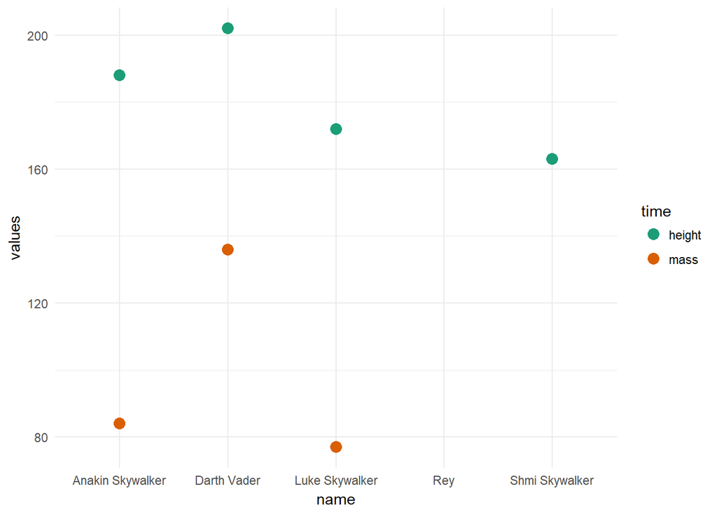

```r
library(ggplot2)

data("starwars")

as.data.frame(starwars) %>%
  filter(species == "Human" & grepl("(Skywalker)|(Rey)|(Vader)|(Kylo)", .$name)) %>%
  select(name, height, mass) %>%
  reshape(., idvar = "name", v.names = "values", varying = list(2:3),
          times = c("height", "mass"), direction = "long") %>%
  ggplot(., aes(x = name, y = values, color = time)) +
  geom_point(size = 3.5) +
  scale_color_brewer(palette = "Dark2") +
  theme_minimal()
```

## reshape

Let’s use the reshape package to do the same thing. You are going to notice a few differences in the function arguments. The reshape packages have this notion of melting (going from wide to long) and casting (going from long to wide). Melting makes plenty of sense to me, but I can only imagine what casting means.

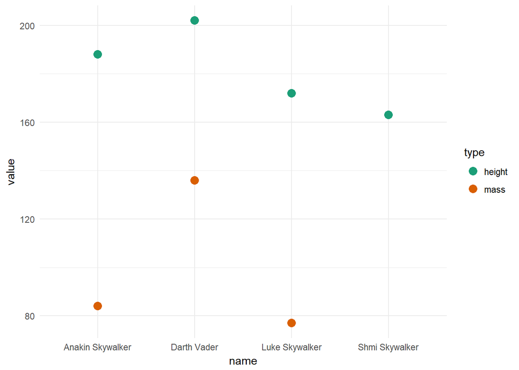

```r
starwars %>%
  as.data.frame() %>%
  filter(species == "Human" &
           grepl("(Skywalker)|(Rey)|(Vader)|(Kylo)",
                 .$name)) %>%
  select(name, height, mass) %>%
  reshape::melt.data.frame(., id.vars = "name",
                           measure.vars = 2:3,
                           variable_name = "type", na.rm = TRUE) %>%
  ggplot(., aes(x = name, y = value, color = type)) +
  geom_point(size = 3.5) +
  scale_color_brewer(palette = "Dark2") +
  theme_minimal()
```

Reshape introduced the vernacular, but I really do not see a reason to use it anymore.

## reshape2

We don’t need to worry about the tibble issue with reshape2!

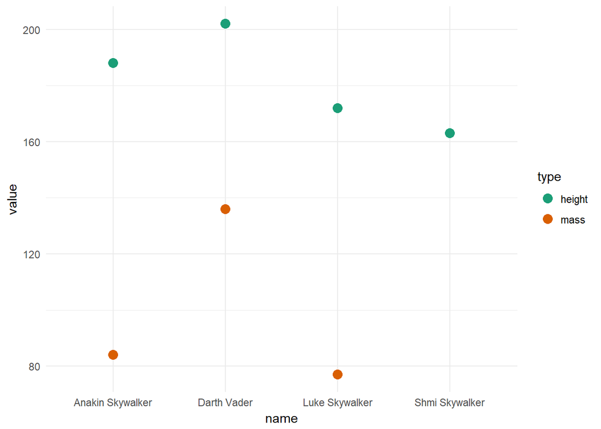

```r
starwars %>%
  filter(species == "Human" & grepl("(Skywalker)|(Rey)|(Vader)|(Kylo)", .$name)) %>%
  select(name, height, mass) %>%
  reshape2::melt(., id.vars = "name",
                           measure.vars = 2:3, variable.name = "type",
                           value.name = "value", na.rm = TRUE) %>%
  ggplot(., aes(x = name, y = value, color = type)) +
  geom_point(size = 3.5) +
  scale_color_brewer(palette = "Dark2") +
  theme_minimal()
```